# Ala Alrababah

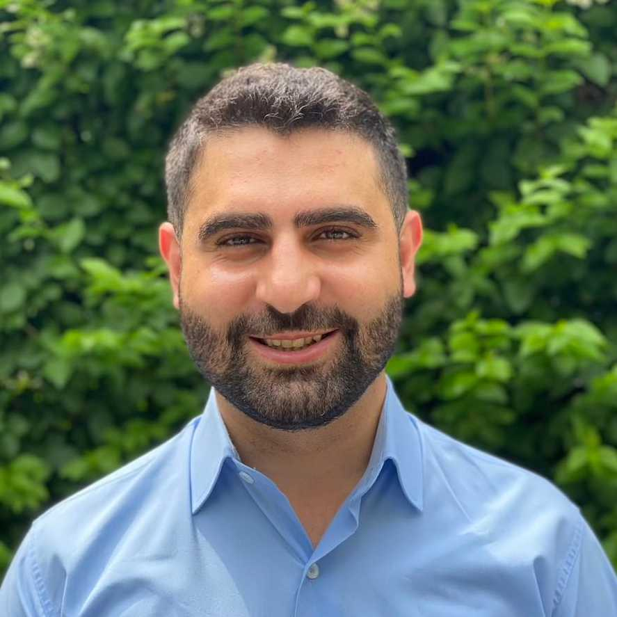

I am an Assistant Professor in the Department of Social and Political Sciences at Bocconi University. Previously, I was a Postdoctoral Fellow at the Immigration Policy Lab, ETH Zurich. I received my Ph.D. in political science from Stanford University in 2021.

My primary research is in comparative politics and international relations with a focus on authoritarian media, political violence, and immigration and refugees. To study these topics, my research combines fieldwork with experimental and computational methods.

My research has been published or is forthcoming in the Proceedings of the National Academy of Sciences, the American Political Science Review, the British Journal of Political Science, Comparative Political Studies, Political Analysis, International Studies Quarterly, and Political Science Research and Methods. It has also been covered in several popular outlets, including [Freakonomics](http://freakonomics.com/podcast/london-live/), [BBC Arabic](https://twitter.com/BBCArabic/status/1142015205314125824), [The Economist](https://www.economist.com/middle-east-and-africa/2021/01/07/making-life-hard-for-syrian-refugees-will-not-compel-them-to-leave), [The Times](https://www.thetimes.co.uk/article/mo-salah-success-scores-home-win-against-islamophobia-in-liverpool-6dnhttvp0), [The Daily Mail](https://www.dailymail.co.uk/news/article-7102863/Islamophobia-plummeted-Liverpool-Egyptian-footballer-Mo-Salah-signed-researchers-say.html), Al Jazeera, [Spiegel Online](https://www.spiegel.de/panorama/mohamed-salah-fc-liverpool-stuermer-laesst-islamfeindlichkeit-sinken-a-1270644.html), [Le Figaro](http://www.lefigaro.fr/le-scan-sport/2019/06/05/27001-20190605ARTFIG00034-la-signature-de-salah-a-liverpool-aurait-provoque-une-baisse-des-crimes-anti-musulmans.php), la Republica, and Al-Araby Al-Jadeed.

You can contact me via email at ala.alrababah [at] unibocconi.it